# IMPORTANCIA DEL ESTUDIO DE TIEMPOS EN LAS EMPRESAS

# Situación problema que tratarás en el trabajo.

El estudio de tiempo es utilizado en la actualidad en la mayoría de las empresas, puesto que permite determinar el tiempo que requiere cada proceso y de esta manera evitar la presencia de un porcentaje alto de improductividad que afecta la eficiencia del trabajo que se realiza, con la finalidad de aprovechar todos los recursos disponibles.

# Identificación de al menos 3 artículos científicos y un libro en el que puedas encontrar soluciones propuestas a la situación problema.

Como libros de referencia para el problema estudiado, se menciona a los libros:

Ingenieria de Metodos movimientos y tiempos de Luis Carlos Palacios Acero, donde se menciona que mejorar el rendimiento de los procesos ayuda a incrementar la productividad y eficiencia, esto se da corrigiendo las fuentes de ineficiencias y desperdicios, cuyo objetivo final es contribuir al progreso empresarial.

Estudios de tiempos y movimientos para la manufactura agil de Fred E. Meyers, se hace énfasis en el diseño y análisis de los puestos de trabajo, y las técnicas para la estandarización de tiempos. La mano de obra en las empresas representan costos significativos en caso de no realizar un buen analisis del estudio de movimientos, por ello se debe controlar el rendimiento de operación.

Articulo ¿Qué ha pasado con la aplicación del estudio de tiempos y movimientos en las últimas dos décadas? de Alex Mauricio Ovalle Castiblanco, Diana María Cárdenas Aguirre, en los ultimos años la globalización y competencia ha obligado a las empresas a evolucionar en técnicas y metodos de trabajo con el objeto de optimizar los tiempos de trabajo, y no tener despilfarros de tiempo, materiales, espacio y demás recursos organizacionales.

# Disponer de un dataset (puede ser datos de excel) sobre la situación problema (Si no dispones de datos puedes buscarlos en sitios como Kaggle).

Se tomo como datos el siguiente archivo:

```r
library(readxl)
tiempo <- read_excel("tiempo.xlsx")
```

# Hacer un análisis exploratorio de los datos.

En la tabla de datos a continuacion se puede observar el estudio de tiempos en unidades productivas de marroquineria, que seran denominados como UP1, UP2, UP3, UP4, UP5, UP6 Y UP7, donde se tienen los datos de tiempos de utilizacion de mano de obra, tiempo de utilizacion de maquinaria, tiempo muerto y en la ultima columna se puede apreciar las cantidades producidas en unidades, mismos que dependen del tiempo empleado en la produccion.

```r
summary(tiempo)
```

```
##  Unidad productiva     Periodo    Tiempo MO     Tiempo maquinaria
##  Length:35          Min.   :1   Min.   :6.000   Min.   :3.340
##  Class :character   1st Qu.:2   1st Qu.:6.645   1st Qu.:3.855
##  Mode  :character   Median :3   Median :7.250   Median :4.140
##                     Mean   :3   Mean   :7.389   Mean   :4.439
##                     3rd Qu.:4   3rd Qu.:8.080   3rd Qu.:5.025
##                     Max.   :5   Max.   :8.980   Max.   :5.930
##  Tiempo muerto   Cantidad producida
##  Min.   :0.370   Min.   :30.00
##  1st Qu.:2.215   1st Qu.:36.50
##  Median :2.800   Median :40.00
##  Mean   :2.812   Mean   :41.51
##  3rd Qu.:3.410   3rd Qu.:49.00
##  Max.   :5.560   Max.   :55.00
```

# Establecer si existe correlación entre las columnas del dataset.

```r
library(ggplot2)
library(corrplot)
mtcars <- read_excel("tiempo.xlsx")
head(mtcars)
```

```
## # A tibble: 6 x 6
##   `Unidad productiva` Periodo `Tiempo MO` `Tiempo maquinaria` `Tiempo muerto`
##   <chr>                 <dbl>       <dbl>               <dbl>           <dbl>
## 1 UP1                       1        6.07                5.78            2.93
## 2 UP1                       2        7.91                4.93            3.09
## 3 UP1                       3        7.25                3.93            2.75
## 4 UP1                       4        6.15                3.98            3.85
## 5 UP1                       5        6.62                5.63            3.38
## 6 UP2                       1        6.67                3.53            3.33
## # ... with 1 more variable: Cantidad producida <dbl>
```

```r
mtcars$`Unidad productiva`=NULL
mtcars.cor <- cor(mtcars,method = "pearson")

round(mtcars.cor,digits = 2)
```

```
##                    Periodo Tiempo MO Tiempo maquinaria Tiempo muerto
## Periodo               1.00      0.09             -0.14         -0.24
## Tiempo MO             0.09      1.00             -0.13         -0.58
## Tiempo maquinaria    -0.14     -0.13              1.00         -0.03
## Tiempo muerto        -0.24     -0.58             -0.03          1.00
## Cantidad producida    0.17      0.66             -0.02         -0.66
##                    Cantidad producida
## Periodo                          0.17
## Tiempo MO                        0.66
## Tiempo maquinaria               -0.02
## Tiempo muerto                   -0.66
## Cantidad producida               1.00
```

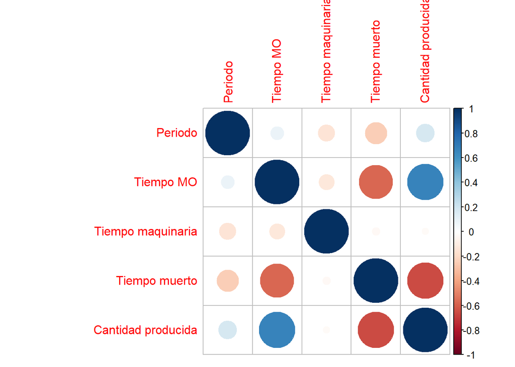

```r
corrplot(mtcars.cor)
```

```r
library(psych)
```

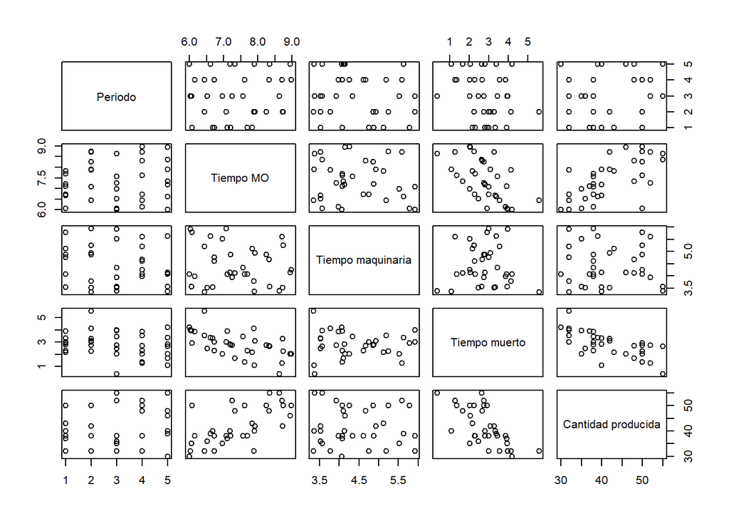

```r
pairs(tiempo[c(2,3,4,5,6)])
```

# Estudiar el histograma , el gráfico de densidad y los cuantiles de la variable que más impacta sobre el problema.

# HISTOGRAMA

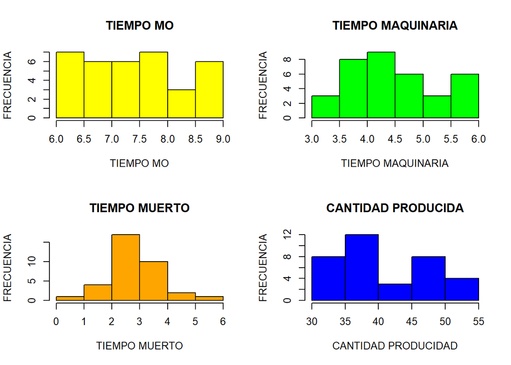

```r
par(mfrow=c(2,2))
hist(tiempo$`Tiempo MO`, col = "yellow", main = "TIEMPO MO", xlab = "TIEMPO MO",ylab = "FRECUENCIA")
hist(tiempo$`Tiempo maquinaria`, col = "green", main = "TIEMPO MAQUINARIA", xlab = "TIEMPO MAQUINARIA", ylab = "FRECUENCIA")
hist(tiempo$`Tiempo muerto`, col = "orange", main = "TIEMPO MUERTO", xlab = "TIEMPO MUERTO", ylab = "FRECUENCIA")
hist(tiempo$`Cantidad producida`, col = "blue", main = "CANTIDAD PRODUCIDA", xlab = "CANTIDAD PRODUCIDAD", ylab = "FRECUENCIA")
```

# DENSIDAD

```r
density(tiempo$`Tiempo MO`)
```

```
##
## Call:
##  density.default(x = tiempo$`Tiempo MO`)
##
## Data: tiempo$`Tiempo MO` (35 obs.);  Bandwidth 'bw' = 0.4108
##
##        x                y
##  Min.   : 4.768   Min.   :0.0006996
##  1st Qu.: 6.129   1st Qu.:0.0434850
##  Median : 7.490   Median :0.2191933
##  Mean   : 7.490   Mean   :0.1834469
##  3rd Qu.: 8.851   3rd Qu.:0.3030407
##  Max.   :10.212   Max.   :0.3424778
```

```r
density(tiempo$`Tiempo maquinaria`)
```

```
##
## Call:
##  density.default(x = tiempo$`Tiempo maquinaria`)
##
## Data: tiempo$`Tiempo maquinaria` (35 obs.);  Bandwidth 'bw' = 0.3551
##
##        x               y
##  Min.   :2.275   Min.   :0.0008247
##  1st Qu.:3.455   1st Qu.:0.0500045
##  Median :4.635   Median :0.2322119
##  Mean   :4.635   Mean   :0.2115908
##  3rd Qu.:5.815   3rd Qu.:0.3310690
##  Max.   :6.995   Max.   :0.4618091
```

```r
density(tiempo$`Tiempo muerto`)
```

```
##
## Call:
##  density.default(x = tiempo$`Tiempo muerto`)
##
## Data: tiempo$`Tiempo muerto` (35 obs.);  Bandwidth 'bw' = 0.3942
##
##        x                 y
##  Min.   :-0.8125   Min.   :0.0003256
##  1st Qu.: 1.0762   1st Qu.:0.0205161
##  Median : 2.9650   Median :0.0640948
##  Mean   : 2.9650   Mean   :0.1322225
##  3rd Qu.: 4.8538   3rd Qu.:0.2493137
##  Max.   : 6.7425   Max.   :0.3994993
```

```r
density(tiempo$`Cantidad producida`)
```

```
##
## Call:
##  density.default(x = tiempo$`Cantidad producida`)
##
## Data: tiempo$`Cantidad producida` (35 obs.); Bandwidth 'bw' = 3.268
##
##        x               y
##  Min.   :20.20   Min.   :6.558e-05
##  1st Qu.:31.35   1st Qu.:4.171e-03
##  Median :42.50   Median :2.619e-02
##  Mean   :42.50   Mean   :2.239e-02
##  3rd Qu.:53.65   3rd Qu.:3.362e-02
##  Max.   :64.80   Max.   :5.181e-02
```

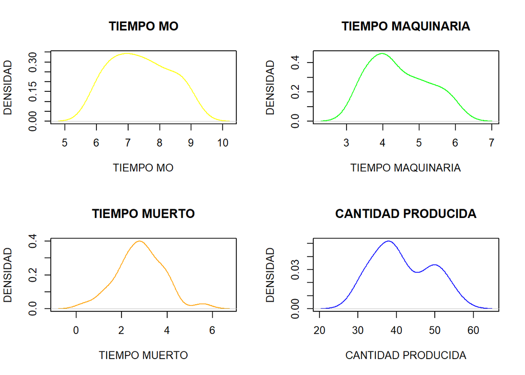

```r
par(mfrow=c(2,2))
plot(density(tiempo$`Tiempo MO`), xlab = "TIEMPO MO", ylab = "DENSIDAD", main = "TIEMPO MO", col="yellow")
plot(density(tiempo$`Tiempo maquinaria`), xlab = "TIEMPO MAQUINARIA", ylab = "DENSIDAD", main = "TIEMPO MAQUINARIA", col="green")
plot(density(tiempo$`Tiempo muerto`), xlab = "TIEMPO MUERTO", ylab = "DENSIDAD", main = "TIEMPO MUERTO", col="orange")
plot(density(tiempo$`Cantidad producida`), xlab = "CANTIDAD PRODUCIDA", ylab = "DENSIDAD", main = "CANTIDAD PRODUCIDA", col="blue")
```

# CUANTILES

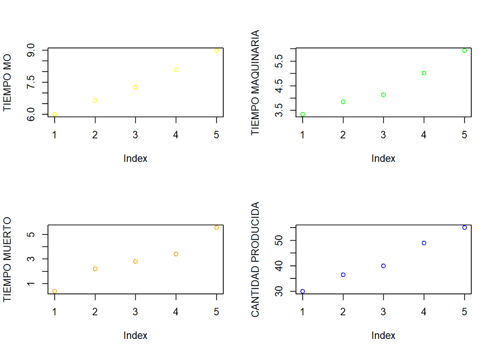

```r
par(mfrow=c(2,2))
plot(quantile(tiempo$`Tiempo MO`), ylab = "TIEMPO MO", col="yellow")
plot(quantile(tiempo$`Tiempo maquinaria`), ylab = "TIEMPO MAQUINARIA", col="green")
plot(quantile(tiempo$`Tiempo muerto`), ylab = "TIEMPO MUERTO", col="orange")
plot(quantile(tiempo$`Cantidad producida`), ylab = "CANTIDAD PRODUCIDA", col="blue")
```

# Bibliografia

Acero, L. C. P. (2017). ingenieria de metodos movimientos y tiempos (Vol. 1) [Libro electrónico]. ecoe ediciones. https://www.ecoeediciones.com/wp-content/uploads/2015/08/Ingenier%C3%ADa-de-m%C3%A9todos.pdf

Freivalds. (2021). Ingenieria Industrial De Niebel Metodos, Estandares y Diseño del Trabajo (13.a ed., Vol. 1) [Libro electrónico]. MCGRAW HILL EDDUCATION. https://www.academia.edu/36652836/Ingenier%C3%ADa_Industrial_M%C3%A9todos_Est%C3%A1ndares_y_Dise%C3%B1o_del_Trabajo_Benjamin_W_Niebel_12_Edici%C3%B3n

Ovalle Castiblanco, A. M., & Cárdenas Aguirre, D. M. (2016, diciembre). ¿Qué ha pasado con la aplicación del estudio de tiempos y movimientos en las últimas dos décadas? DIALNET. https://dialnet.unirioja.es/servlet/articulo?codigo=6096114